# NYC Shootings Analysis

Tristan Osborn

2024-04-22

## Data

#### The data for this project is the NYPD Shooting Incident Data (Historic) dataset from data.gov published by The City of New York. Source:https://data.cityofnewyork.us/api/views/833y-fsy8/rows.csv?accessType=DOWNLOAD

#### According to the description, “This data is manually extracted every quarter and reviewed by the Office of Management Analysis and Planning before being posted on the NYPD website. Each record represents a shooting incident in NYC and includes information about the event, the location and time of occurrence. In addition, information related to suspect and victim demographics is also included. This data can be used by the public to explore the nature of shooting/criminal activity”. The dates for the shootings range from 2006 to 2022.

```r
#tidyverse and data
library(tidyverse)
library(dplyr)
#reading in data
df <- read_csv('https://data.cityofnewyork.us/api/views/833y-fsy8/rows.csv?accessType=DOWNLOAD')
summary(df)
```

```
##   INCIDENT_KEY        OCCUR_DATE         OCCUR_TIME           BORO
##  Min.   :  9953245   Length:27544       Length:27544      Length:27544
##  1st Qu.: 64116659   Class :character   Class1:hms        Class :character
##  Median : 90929326   Mode  :character   Class2:difftime   Mode  :character
##  Mean   :122219358                      Mode  :numeric
##  3rd Qu.:191557724
##  Max.   :284961340
##
##  LOC_OF_OCCUR_DESC     PRECINCT      JURISDICTION_CODE LOC_CLASSFCTN_DESC
##  Length:27544       Min.   :  1.00   Min.   :0.0000    Length:27544
##  Class :character   1st Qu.: 44.00   1st Qu.:0.0000    Class :character
##  Mode  :character   Median : 67.00   Median :0.0000    Mode  :character
##                     Mean   : 65.58   Mean   :0.3256
##                     3rd Qu.: 81.00   3rd Qu.:0.0000
##                     Max.   :123.00   Max.   :2.0000
##                                      NA's   :2
##  LOCATION_DESC      STATISTICAL_MURDER_FLAG PERP_AGE_GROUP
##  Length:27544       Mode :logical           Length:27544
##  Class :character   FALSE:22225             Class :character
##  Mode  :character   TRUE :5319              Mode  :character
##
##
##
##
##    PERP_SEX          PERP_RACE         VIC_AGE_GROUP        VIC_SEX
##  Length:27544       Length:27544       Length:27544       Length:27544
##  Class :character   Class :character   Class :character   Class :character
##  Mode  :character   Mode  :character   Mode  :character   Mode  :character
##
##
##
##
##    VIC_RACE           X_COORD_CD        Y_COORD_CD        Latitude
##  Length:27544       Min.   : 914928   Min.   :125757   Min.   :40.51
##  Class :character   1st Qu.:1000042   1st Qu.:182857   1st Qu.:40.67
##  Mode  :character   Median :1007753   Median :194668   Median :40.70
##                     Mean   :1009461   Mean   :208217   Mean   :40.74
##                     3rd Qu.:1016838   3rd Qu.:239570   3rd Qu.:40.82
##                     Max.   :1066815   Max.   :271128   Max.   :40.91
##                                                        NA's   :16
##    Longitude        Lon_Lat
##  Min.   :-74.25   Length:27544
##  1st Qu.:-73.94   Class :character
##  Median :-73.92   Mode  :character
##  Mean   :-73.91
##  3rd Qu.:-73.88
##  Max.   :-73.70
##  NA's   :16
```

## Potential Bias

#### There are multiple columns that can be may be valuable to analysis of the data, but I want to narrow it down to time based analysis and focus on the year, month, day of week, etc. This means I will only focus on Occur Date and Occur Time. Therefore, columns such as Sex, Race, and Borough may add bias to our models.

```r
# checking missing data
sum(is.na(df$OCCUR_DATE))
```

```
## [1] 0
```

```r
sum(is.na(df$OCCUR_TIME))
```

```
## [1] 0
```

#### We can see that there aren’t missing data in the fields we need, OCCUR_DATE & OCCUR_TIME.

```r
#formatting date/time
df <- df %>%mutate(OCCUR_DATE = as.Date(OCCUR_DATE, format="%m/%d/%Y"),OCCUR_TIME = as.POSIXct(OCCUR_TIME,format="%H:%M"))
#filtering data
df <- df %>%
  filter(OCCUR_DATE >= as.Date("2006-01-01") & OCCUR_DATE <= as.Date("2022-12-31"))
#getting year, month, hour, and day of the week
df <- df %>%mutate(YEAR = year(OCCUR_DATE), MONTH = month(OCCUR_DATE, label=TRUE),HOUR = hour(OCCUR_TIME),DAY_OF_WEEK = wday(OCCUR_DATE, label=TRUE, abbr=FALSE))
```

```r
#getting year, month, day, and hour averages
yearly_avgs <- df %>% count(YEAR) %>% mutate(AVERAGE = n / 12)
monthly_avgs <- df %>% count(MONTH) %>% mutate(AVERAGE = n / n_distinct(df$YEAR))
hourly_avgs <- df %>% count(HOUR) %>% mutate(AVERAGE = n / (n_distinct(df$YEAR) * 365 * 24))
daily_avgs <- df %>%count(DAY_OF_WEEK) %>% mutate(DAY_OF_WEEK = factor(DAY_OF_WEEK, levels=c("Sunday", "Monday", "Tuesday", "Wednesday", "Thursday", "Friday", "Saturday")), AVERAGE = n / (n_distinct(df$YEAR) * 52))
```

## Average Monthly Shootings by Year

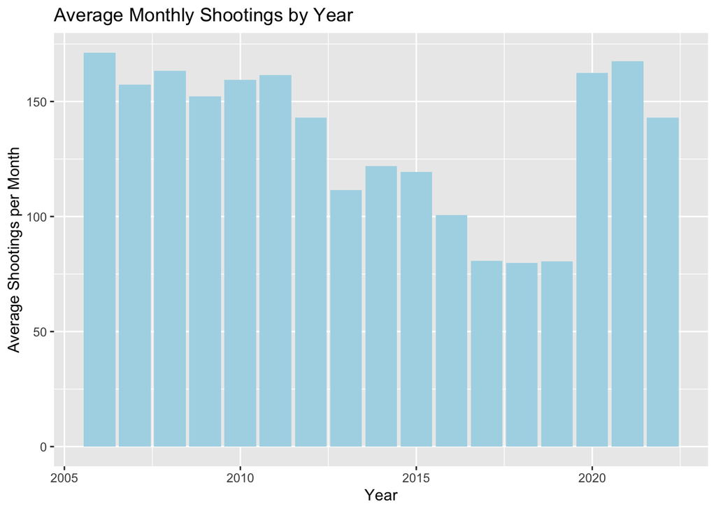

```r
#avg yearly shooting plot
ggplot(yearly_avgs, aes(x = YEAR, y = AVERAGE)) + geom_col(fill = "lightblue") +
  labs(title = "Average Monthly Shootings by Year", x = "Year", y = "Average Shootings per Month")
```

## Average Shootings by Month

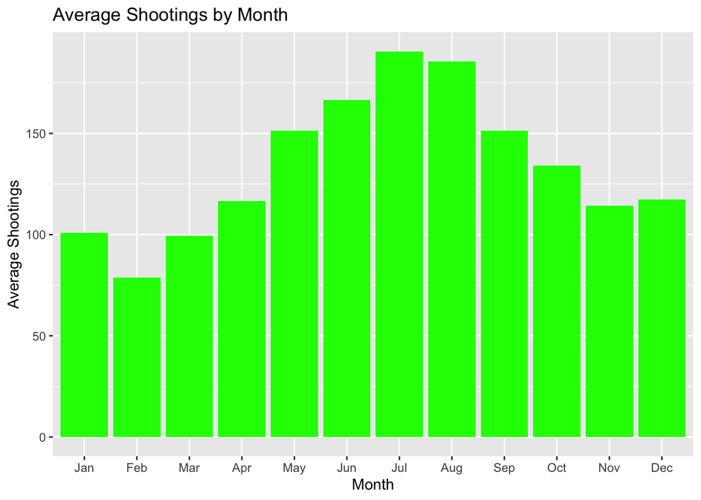

```r
#avg monthly shooting plot
ggplot(monthly_avgs, aes(x = MONTH, y = AVERAGE)) + geom_col(fill = "green") +
  labs(title = "Average Shootings by Month", x = "Month", y = "Average Shootings")
```

#### It appears that more shootings occur during the summer months and less during the winter. A possibility is that the cold weather means less people outside, therefore less chances of shooting/being shot.

## Average Shootings by Day of the Week

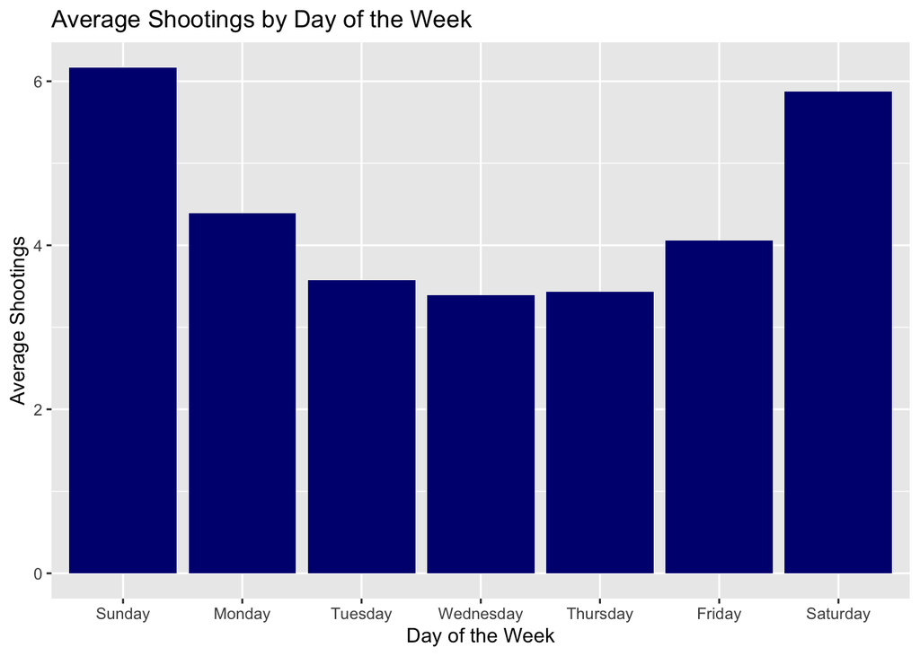

```r
#avg daily shooting plot
ggplot(daily_avgs, aes(x = DAY_OF_WEEK, y = AVERAGE)) +
  geom_col(fill = "navy") +
  labs(title = "Average Shootings by Day of the Week", x = "Day of the Week", y = "Average Shootings")
```

#### Most shootings occur on weekends on average. Similar to the month, there may be more people out and about while off on the weekend and less of a chance as to be on either end of a shooting during the work week.

## Average Shootings by Hour

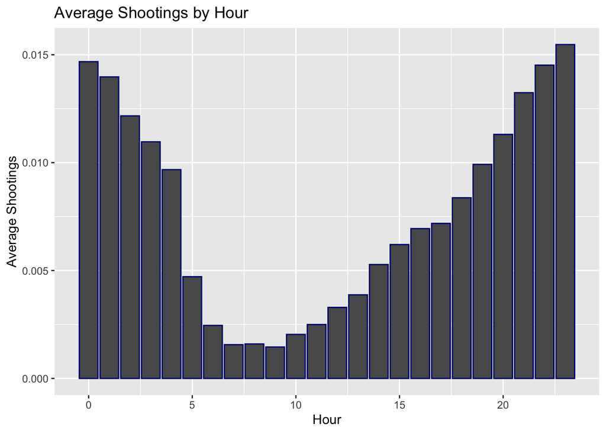

```r
#avg hourly shooting plot
ggplot(hourly_avgs, aes(x = HOUR, y = AVERAGE)) +
  geom_col(color = "navy") + labs(title = "Average Shootings by Hour", x = "Hour", y = "Average Shootings")
```

#### Most shootings occur between around 6pm and 4am. The majority of shootings happen overnight. Potential reasons for this could be reduced visibility, or because there may be less crowded streets due to businesses closing.

# Models

## Year

### Linear Model

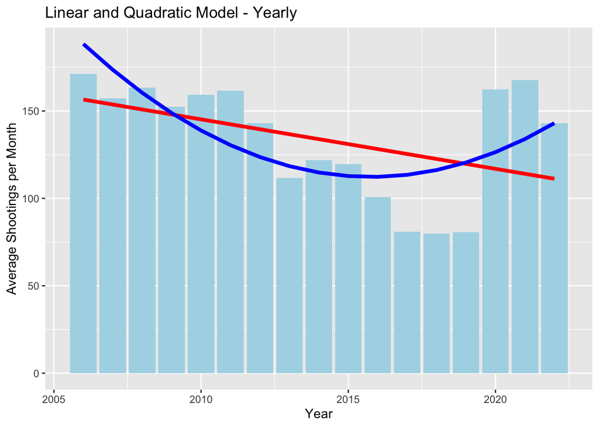

```r
#linear
lin_model_yearly <- lm(AVERAGE ~ YEAR, data = yearly_avgs)

#quadratcic
yearly_avgs <- yearly_avgs %>% mutate(year_squared = YEAR^2)
quad_model_yearly <- lm(AVERAGE ~ YEAR + year_squared, data = yearly_avgs)

# plot
ggplot(yearly_avgs, aes(x = YEAR)) +
  geom_col(aes(y = AVERAGE), fill = "lightblue") +
  geom_line(aes(y = predict(lin_model_yearly)), color = "red", linewidth = 1.5) +
  geom_line(aes(y = predict(quad_model_yearly)), color = "blue", linewidth = 1.5) +
labs(title = "Linear and Quadratic Model - Yearly", x = "Year", y = "Average Shootings per Month")
```

```r
#summary
summary_linear_yearly <- summary(lin_model_yearly)
summary_quadratic_yearly <- summary(quad_model_yearly)

# Printing Monthly Model Adjusted R-squared values rounded to two decimal places
cat("Yearly Linear Model Adjusted r^2:", round(summary_linear_yearly$adj.r.squared, 2), "\n")
```

```
## Yearly Linear Model Adjusted r^2: 0.14
```

```r
cat("Yearly Quadratic Model Adjusted r^2:", round(summary_quadratic_yearly$adj.r.squared, 2), "\n")
```

```
## Yearly Quadratic Model Adjusted r^2: 0.4
```

## Months

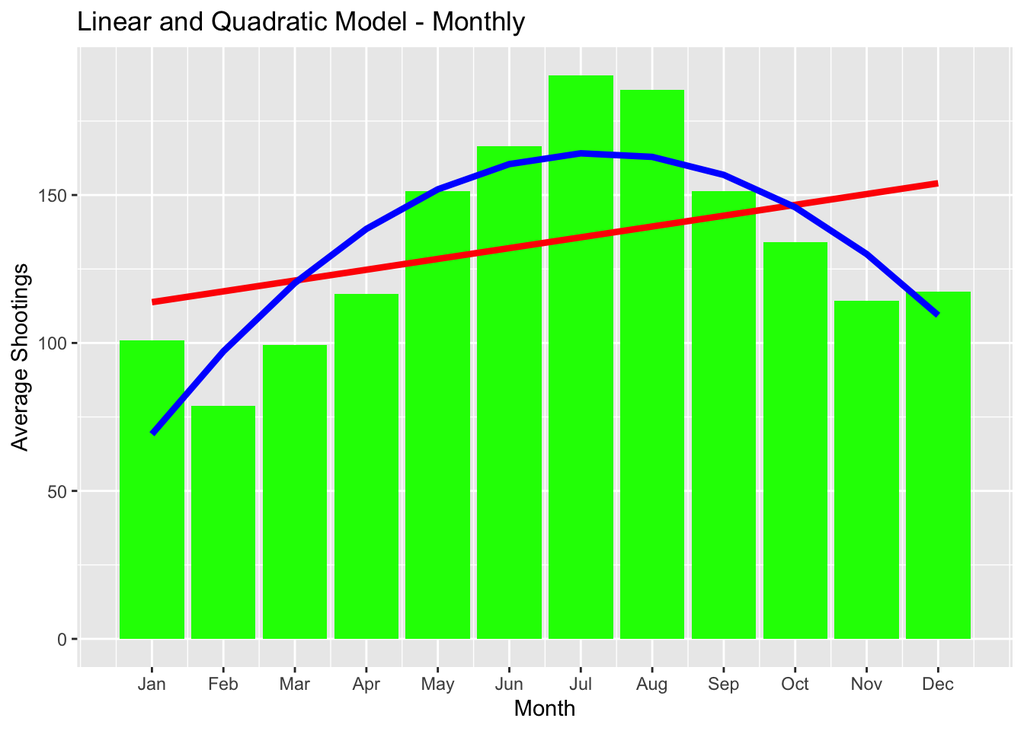

```r
#linear
monthly_avgs$MONTH_NUM <- as.numeric(as.factor(monthly_avgs$MONTH))
lin_model_month <- lm(AVERAGE ~ MONTH_NUM, data = monthly_avgs)

#quadratic
monthly_avgs <- monthly_avgs %>% mutate(month_squared = MONTH_NUM^2)
quad_model_month <- lm(AVERAGE ~ MONTH_NUM + month_squared, data = monthly_avgs)

#plotting models
ggplot(monthly_avgs, aes(x = MONTH_NUM)) +
  geom_col(aes(y = AVERAGE), fill = "green") +
  geom_line(aes(y = predict(lin_model_month)), color = "red", linewidth = 1.5) +
  geom_line(aes(y = predict(quad_model_month)), color = "blue", linewidth = 1.5) +
  labs(title = "Linear and Quadratic Model - Monthly", x = "Month", y = "Average Shootings") +
  scale_x_continuous(breaks = 1:12, labels = levels(as.factor(monthly_avgs$MONTH)))
```

```r
#summary
summary_linear_month <- summary(lin_model_month)
summary_quadratic_month <- summary(quad_model_month)

# Printing Monthly Model Adjusted R-squared values rounded to two decimal places
cat("Monthly Linear Model Adjusted r^2:", round(summary_linear_month$adj.r.squared, 2), "\n")
```

```
## Monthly Linear Model Adjusted r^2: 0.05
```

```r
cat("Monthly Quadratic Model Adjusted r^2:", round(summary_quadratic_month$adj.r.squared, 2), "\n")
```

```
## Monthly Quadratic Model Adjusted r^2: 0.65
```

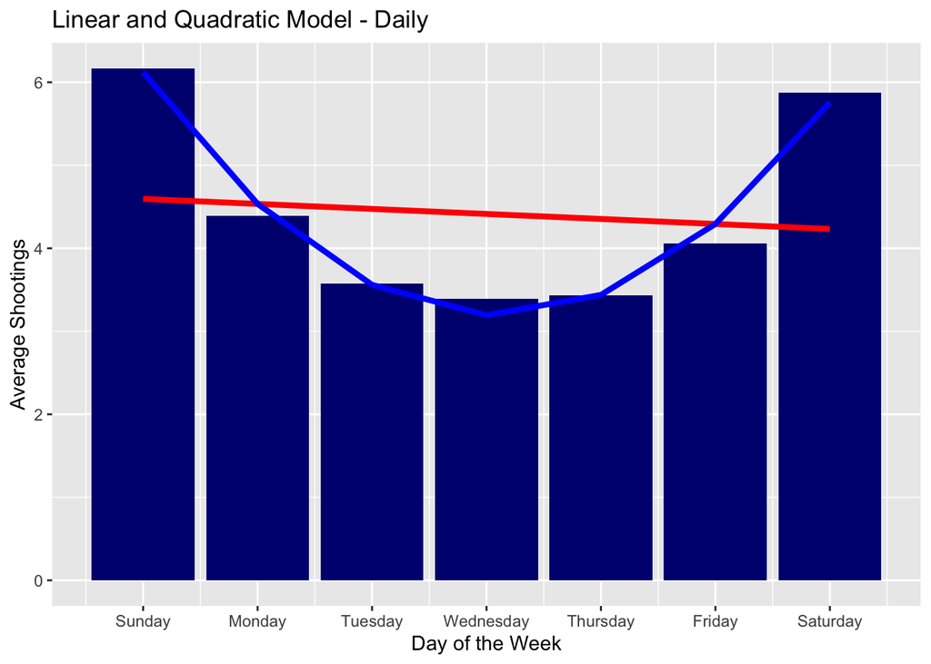

```r
#linear
daily_avgs$DAY_NUM <- as.numeric(as.factor(daily_avgs$DAY_OF_WEEK))
lin_model_daily <- lm(AVERAGE ~ DAY_NUM, data = daily_avgs)

#quadratic
daily_avgs <- daily_avgs %>% mutate(day_squared = DAY_NUM^2)
quad_model_daily <- lm(AVERAGE ~ DAY_NUM + day_squared, data = daily_avgs)

#plot
ggplot(daily_avgs, aes(x = DAY_NUM)) +
  geom_col(aes(y = AVERAGE), fill = "navy") +
  geom_line(aes(y = predict(lin_model_daily)), color = "red", linewidth = 1.5) +
  geom_line(aes(y = predict(quad_model_daily)), color = "blue", linewidth = 1.5) +
  labs(title = "Linear and Quadratic Model - Daily", x = "Day of the Week", y = "Average Shootings") +
  scale_x_continuous(breaks = 1:7, labels = c("Sunday", "Monday", "Tuesday", "Wednesday", "Thursday", "Friday", "Saturday"))
```

```r
#summaries
summary_linear_daily <- summary(lin_model_daily)
summary_quadratic_daily <- summary(quad_model_daily)

#printing
cat("Daily Linear Model Adjusted r^2:", round(summary_linear_daily$adj.r.squared, 2), "\n")
```

```
## Daily Linear Model Adjusted r^2: -0.18
```

```r
cat("Daily Quadratic Model Adjusted r^2:", round(summary_quadratic_daily$adj.r.squared, 2), "\n")
```

```
## Daily Quadratic Model Adjusted r^2: 0.98
```

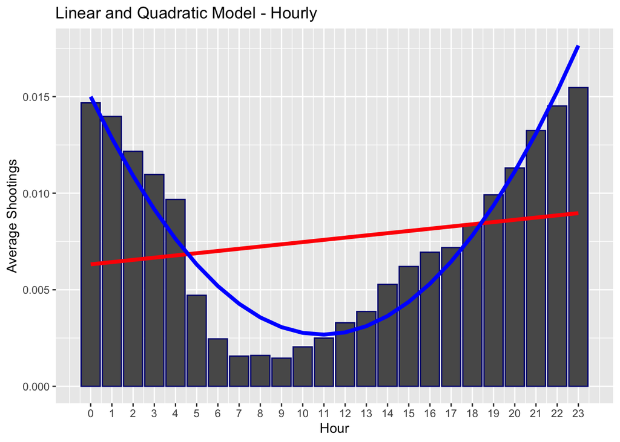

```r
#linear
lin_model_hourly <- lm(AVERAGE ~ HOUR, data = hourly_avgs)

#quad
hourly_avgs <- hourly_avgs %>% mutate(hour_squared = HOUR^2)
quad_model_hourly <- lm(AVERAGE ~ HOUR + hour_squared, data = hourly_avgs)

#plot
ggplot(hourly_avgs, aes(x = HOUR)) +
  geom_col(aes(y = AVERAGE), color = "navy") +
  geom_line(aes(y = predict(lin_model_hourly)), color = "red", linewidth = 1.5) +
  geom_line(aes(y = predict(quad_model_hourly)), color = "blue", linewidth = 1.5) +
  labs(title = "Linear and Quadratic Model - Hourly", x = "Hour", y = "Average Shootings") +
  scale_x_continuous(breaks = seq(0, 23, by = 1), labels = as.integer(seq(0, 23, by = 1)))
```

```r
#summaries
summary_linear_hourly <- summary(lin_model_hourly)
summary_quadratic_hourly <- summary(quad_model_hourly)
#printingr2
cat("Hourly Linear Model Adjusted r^2:", round(summary_linear_hourly$adj.r.squared, 2), "\n")
```

```
## Hourly Linear Model Adjusted r^2: -0.02
```

```r
cat("Hourly Quadratic Model Adjusted r^2:", round(summary_quadratic_hourly$adj.r.squared, 2), "\n")
```

```
## Hourly Quadratic Model Adjusted r^2: 0.9
```

## Conclusion

#### We can tell from the graphs and comparing the adjusted r^2 that quadratic regression is performing much better than linear. This was fairly expected as there is a parabolic-y shape in both monthly and yearly results.

#### Overall, we can tell that time is an important factor to shootings in NYC. Trends show that on average: summers, weekends, and overnights are the most likely for a shooting to occur. Just for fun:

```r
#getting predictions
quad_preds_month <- predict(quad_model_month, monthly_avgs)
quad_preds_daily <- predict(quad_model_daily, daily_avgs)
quad_preds_hourly <- predict(quad_model_hourly, hourly_avgs)

#getting max values
max_month_quad <- monthly_avgs %>% arrange(desc(quad_preds_month)) %>% slice(1) %>% pull(MONTH)
max_day_quad <- daily_avgs %>% arrange(desc(quad_preds_daily)) %>% slice(1) %>% pull(DAY_OF_WEEK)
max_hour_quad <- hourly_avgs %>% arrange(desc(quad_preds_hourly)) %>% slice(1) %>% pull(HOUR)

#printing results
cat(" month: ", max_month_quad, "\n",
    "day of the week: ", max_day_quad, "\n",
    "hour of day: ", max_hour_quad, "\n")
```

```
##  month:  7
##  day of the week:  1
##  hour of day:  23
```

#### We can see that according to Quadratic models, the single highest chance of a shooting occuring is a Sunday in July around 11pm.